# GameAI

## Project 01 - Simple strategies for turn-based games

## ToDo

- 1.2 - Simple strategies for tic tac toe
  - 1.2.1 - Implement a probabilistic strategy
  - 1.2.2 - Implement a heuristic strategy
- 1.3 - Connect Four

## Task 1.2 - Simple strategies for tic tac toe

- Script -> Object oriented implementation
  - Play multiple games on one instance (`reset_game()`)
  - Collect data in the object

```python
# Import and initiate TicTacToe
from tic_tac_toe_B import TicTacToe
tic_tac_toe = TicTacToe()
```

```python
tic_tac_toe.play_a_game()
```

```
x moves
[[' ' ' ' ' ']
 ['x' ' ' ' ']
 [' ' ' ' ' ']]
o moves
[[' ' ' ' 'o']
 ['x' ' ' ' ']
 [' ' ' ' ' ']]
x moves
[[' ' 'x' 'o']
 ['x' ' ' ' ']
 [' ' ' ' ' ']]
o moves
[[' ' 'x' 'o']
 ['x' ' ' ' ']
 ['o' ' ' ' ']]
x moves
[[' ' 'x' 'o']
 ['x' ' ' ' ']
 ['o' ' ' 'x']]
o moves
[[' ' 'x' 'o']
 ['x' ' ' ' ']
 ['o' 'o' 'x']]
x moves
[[' ' 'x' 'o']
 ['x' ' ' 'x']
 ['o' 'o' 'x']]
o moves
[[' ' 'x' 'o']
 ['x' 'o' 'x']
 ['o' 'o' 'x']]
player o wins after 8 moves
```

```
-1
```

## 1.2.1 - Implement a probabilistic strategy

- Play at least 1000 games
- Count cell contribution to a win
- Normalize count data
- Make player X to 'use' the data
- Play at least 1000 games
- ...

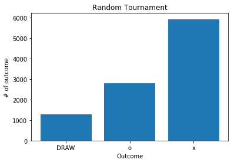

```python
# Plot Barchart of wins and draws
tic_tac_toe.plot_bar(label="Random Tournament", statistics=tournament_results)
```

- ...
- Count cell contribution to a win
- Normalize count data
- ...

```python
# Cell contribution to wins
tic_tac_toe.S_stats
```

```
array([[3487, 2065, 3513],
       [2059, 5026, 2118],
       [3444, 2055, 3536]])
```

```python
# Normalize data and save to a JSON file
tic_tac_toe.normalize_statistics(print_normalization=True)
```

```
Field	Normalized value
0	0.1277149031241988
1	0.07563271435373402
2	0.12866717943083178
3	0.07541295828297256
4	0.18408233527451195
5	0.07757389297879354
6	0.12613998461707504
7	0.07526645423579827
8	0.12950957770208402
```

- ...
- Make player X to 'use' the data

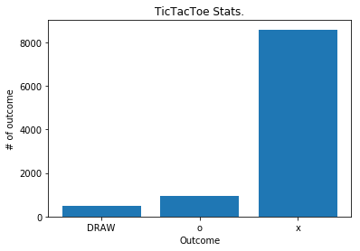

```python
# Plot Barchart of wins and draws
tic_tac_toe.plot_bar(statistics=prob_stats)
```

## 1.2.2 - Implement a heuristic strategy

- Evaluate quality of potential move
- Make player X to follow that strategy
- Evaluate quality of potential move
  - Consider all free positions
  - Select most auspicious one
1. Can I win?
   1. Yes: Put the mark here
   2. No: Continue with 2
2. Can oponent win?
   1. Yes: Put the mark here
   2. No: Continue with 3
3. Apply probabilistic strategy

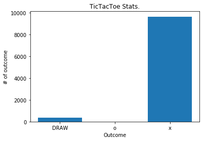

```python
# Plot Barchart of wins and draws
tic_tac_toe.plot_bar(statistics=heu_stats)
```

## Task 1.3 - Connect Four

- Implement basic mechanics
  - Random moves
  - Termination tests
- Play a tournament
  - Try to collect statistics about 'good moves'
- Realize a "beautiful" GUI
  - Observe game progress
  - Possible user input

### Termination tests

[figure not shown]

```
Count_Array = [1, 3, 3, ..., 4]
```

### Collecting statistics about 'good moves'

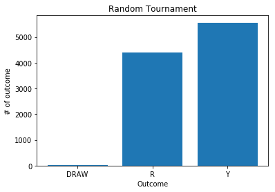

```python
# 10k game tournament results
connect_four.plot_bar(label="Random Tournament", statistics=tournament_results)
```

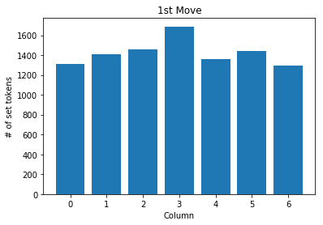

```python
# Using helperfunction to plot
plot_bars(d[0], "1st Move")
```

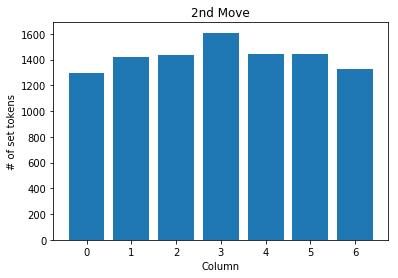

```python
# Using helperfunction to plot
plot_bars(d[1], "2nd Move")
```

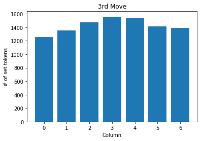

```python
# Using helperfunction to plot
plot_bars(d[2], "3rd Move")
```

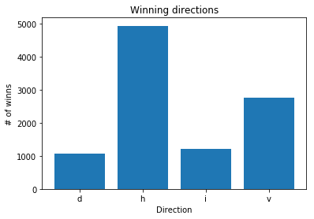

```python
# Using helperfunction to plot
plot_bars(connect_four.stats['win_direction'], "Winning directions", "Direction", "# of winns")
```

### Finding 'good moves'

- Tried to determine good 1st move
- Horizontal patterns seem to be a good 'goal'
- Not trivial to define what a good move is
- Number of possible field configurations is high
  - If a move is good depends on this configuration